# Linear Regression As Probability Model

Lecture 07

February 6, 2026

# Review

## OLS Estimates

- **If the linear model is true**, OLS gives unbiased parameter estimates and (unconditionally) unbiased predictions.
- **Linear regression is often treated as magic**. It is not: estimates are sensitive to data distributions and included variables.

# Linear Regression As A Probability Model

## Probabilistic Assumptions for LR

$$y = \underbrace{\sum_j \beta_j x^j_i}_{\mathbb{E}[y | x^j]} + \underbrace{\varepsilon_i}_{\text{noise}}, \quad \varepsilon_i \sim N(0, \sigma^2)$$

1. $\mathbb{E}[y | x^j]$: Best linear prediction of $y$ conditional on choice of predictors $x^j$.
2. The noise defines the probability distribution (here: Gaussian) of the observations: $y \sim N(\sum_j \beta_j x^j_i), \sigma^2).$

## Why Add Distributional Assumptions?

The distributional assumption of independent Gaussian residuals is **strong**. Why would we add this?

1. We can obtain $\hat{\beta}$ and $\hat{\sigma}$ through **maximum likelihood**. Maximum likelihood works for most probability models and is **asymptotically efficient**.
2. Can estimate sampling distributions, distributions of predictions, other statistical quantities.

## Why Linear Models?

Two main reasons to use Gaussian noise:

1. **Inferential**: “Least informative” distribution assuming only finite mean/variance;
2. **Generative**: Central Limit Theorem (summed fluctuations are asymptotically normal)

[figure not shown]

Weight stack Gaussian distribution

Source: r/GymMemes

## Central Limit Theorem

If

- $\mathbb{E}[X_i] = \mu$
- and $\text{Var}(X_i) = \sigma^2 < \infty$,

$$\begin{aligned}
\lim_{n \to \infty} \sqrt{n}(\bar{X}_n - \mu ) &= \mathcal{N}(0, \sigma^2) \\
\Rightarrow & \bar{X}_n \overset{\text{approx}}{\sim} \mathcal{N}(\mu, \sigma^2/n)
\end{aligned}$$

## Central Limit Theorem (More Intuitive)

For **a large enough set of samples**:

The sampling distribution of a sum or mean of random variables is approximately normal distribution, **even if the random variables themselves are not**.

[figure not shown]

Small n Meme

Source: Unknown

## Implications of Gaussian Noise

Without explicit modeling of sources of measurement uncertainty, in LR we can’t separate a noisy system state (due to *e.g.* omitted variables) from an uncertain measurement error (more on this later).

$$\begin{array}{l}
X \sim N(\mu_1, \sigma_1^2) \\
Y \sim N(\mu_2, \sigma_2^2) \\
Z = X + Y
\end{array}
\qquad \Rightarrow \qquad Z \sim N(\mu_1 + \mu_2, \sigma_1^2 + \sigma_2^2)$$

# Maximum Likelihood

## Example

$$\begin{align*}
S &= \beta_0 + \beta_1 \log(D) + U\\
U &\sim \mathcal{N}(0, \sigma^2)
\end{align*}$$

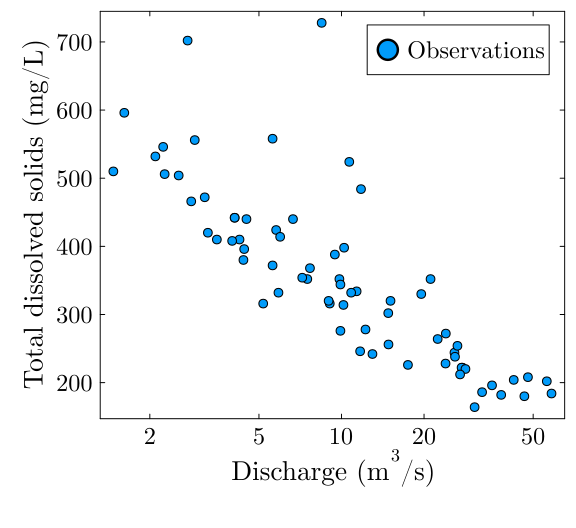

## Likelihood

How do we find $\beta_i$ and $\sigma$?

**Likelihood** of data to have come from distribution $f(\mathbf{x} | \theta)$:
$$\mathcal{L}(\theta | \mathbf{x}) = \underbrace{f(\mathbf{x} | \theta)}_{\text{PDF}}$$

Here the randomness comes from $U$:
$$S \sim \mathcal{N}(\beta_0 + \beta_1 \log(D), \sigma^2)$$

## OLS Solution Maximizes Gaussian Likelihood

$$y_i \sim \mathcal{N}(F(x_i), \sigma^2)$$

$$\mathcal{L}(\theta | \mathbf{y}; F) = \prod_{i=1}^n \frac{1}{\sqrt{2\pi}} \exp(-\frac{y_i - F(x_i)^2}{2\sigma^2})$$

$$\log \mathcal{L}(\theta | \mathbf{y}; F) = \sum_{i=1}^n \left[\log \frac{1}{\sqrt{2\pi}} - \frac{1}{2\sigma^2}(y_i - F(x_i))^2 \right]$$

$$\begin{align}
\log \mathcal{L}(\theta | \mathbf{y}, F) &= \sum_{i=1}^n \left[\log \frac{1}{\sqrt{2\pi}} - \frac{1}{2\sigma^2}(y_i - F(x_i)) ^2 \right] \\
&= n \log \frac{1}{\sqrt{2\pi}} - \frac{1}{2\sigma^2} \sum_{i=1}^n (y_i - F(x_i))^2
\end{align}$$

Ignoring constants (including $\sigma$):

$$\log \mathcal{L}(\theta | \mathbf{y}, F) \propto -\sum_{i=1}^n (y_i - F(x_i))^2.$$

Maximizing $f(x)$ is equivalent to minimizing $-f(x)$:

$$-\log \mathcal{L}(\theta | \mathbf{y}, F) \propto \sum_{i=1}^n (y_i - F(x_i))^2 = \text{MSE}$$

## Back to the Problem…

```julia
# tds_riverflow_loglik: function to compute the log-likelihood for the tds model
# θ: vector of model parameters (coefficients β₀ and β₁ and stdev σ)
# tds, flow: vectors of data
function tds_riverflow_loglik(θ, tds, flow)
    β₀, β₁, σ = θ # unpack parameter vector
    μ = β₀ .+ β₁ * log.(flow) # find mean
    ll = sum(logpdf.(Normal.(μ, σ), tds)) # compute log-likelihood
    return ll
end

lb = [0.0, -1000.0, 1.0]
ub = [1000.0, 1000.0, 100.0]
θ₀ = [500.0, 0.0, 50.0]
optim_out = Optim.optimize(θ -> -tds_riverflow_loglik(θ, tds.tds_mgL, tds.discharge_cms), lb, ub, θ₀)
θ_mle = optim_out.minimizer; digits=0
@show θ_mle;
```

```
θ_mle = [609.5487268719755, -111.63106888212424, 71.52458711451465]
```

**Note**: Should really round these results to account for significant digits. Did not here purely for comparison with OLS.

## Maximum Likelihood Results

[figure not shown]

```julia
# simulate 10,000 predictions
x = 1:0.1:60
μ = θ_mle[1] .+ θ_mle[2] * log.(x)

plot!(p1,
    x,
    μ,
    linewidth=3,
    label="MLE line",
    size=(600, 550))
plot!(p, size=(600, 600))
```

[output not shown]

## Residual Analysis (Patterns)

Important to check if the assumptions of the model held: are the residuals seemingly uncorrelated and normally distributed?

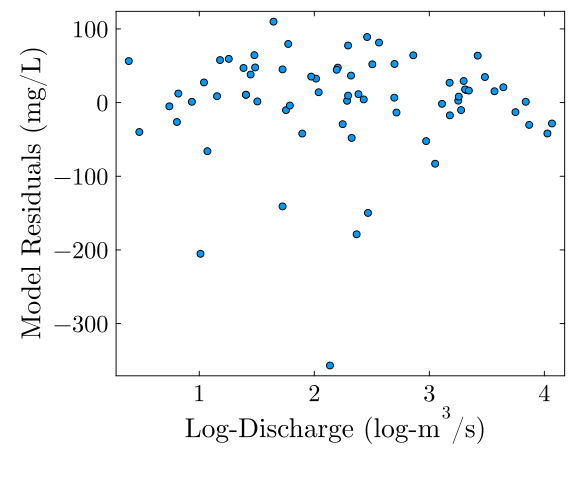

Figure 1: Residuals for the TDS-Riverflow model.

```julia
pred = θ_mle[1] .+ θ_mle[2] * log.(tds.discharge_cms)
resids = pred - tds.tds_mgL
p1 = scatter(log.(tds.discharge_cms), resids, ylabel="Model Residuals (mg/L)", xlabel=L"Log-Discharge (log-m$^3$/s) ", size=(600, 500))
```

## Residual Analysis (Distribution)

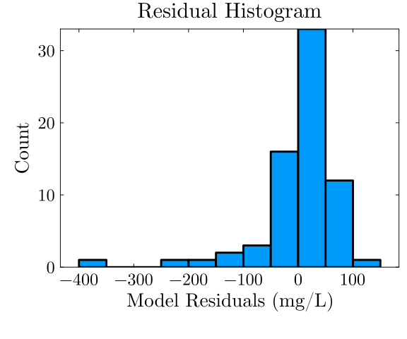

(a) Residuals for the TDS-Riverflow model.

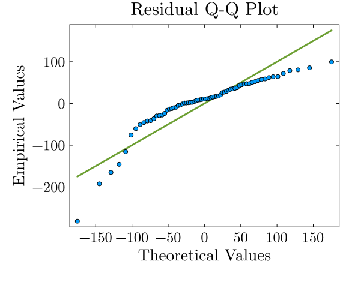

(b)

Figure 2

# Confidence and Predictive Intervals

## What Did We Gain?

The Gaussian-noise assumptions is strong. Why make it?

Now we have conditional distributions for each $y_i$, $p(y_i | X = \mathbf{x}_i)$.

## Value of Conditional Distributions

This lets us:

1. Capture uncertainty in our estimates (sampling distributions);
2. Make probabilistic statements about predictions (*e.g.* what is the 99th quantile).

## Sampling Distributions

Uncertainty can come from randomness of sampling. How does that affect our estimates?

The resulting distribution of estimates is called the **sampling distribution**.

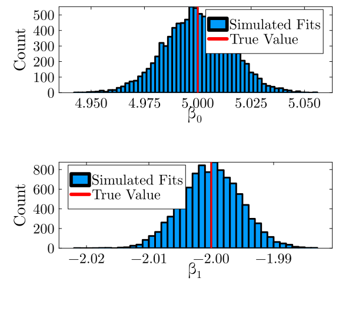

Figure 3: Illustration of sampling distributions

```julia
function sim_lrfit(x, β₀, β₁, σ²; coefficients=true)
    n = length(x)
    y = β₀ .+ β₁ * x .+ rand(Normal(0, σ²), n)
    if coefficients
        mod = lm([ones(n) x], y)
        return [coef(mod); dispersion(mod)]
    else
        return DataFrame(X=x, Y=y)
    end
end

x = rand(Uniform(-5, 5), 42)
# reduce(hcat, v)' turns vector of vectors v into Matrix by concatenating horizontally then transposing
sim_coefs = reduce(hcat, [sim_lrfit(x, 5, -2, 0.1, coefficients=true) for i in 1:10_000])'

p1 = histogram(sim_coefs[:, 1], xlabel=L"β$_0$", ylabel="Count", label="Simulated Fits")
vline!([5], color=:red, linewidth=3, label="True Value")

p2 = histogram(sim_coefs[:, 2], xlabel=L"β$_1$", ylabel="Count", label="Simulated Fits")
vline!([-2], color=:red, linewidth=3, label="True Value", legend=:topleft)

plot(p1, p2, layout=(2, 1), size=(600, 550))
```

## Impact of Greater Noise

What if we ramp up the observation variability?

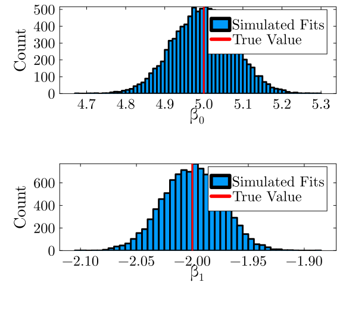

Figure 4: Illustration of sampling distributions

```julia
function sim_lrfit(x, β₀, β₁, σ²; coefficients=true)
    n = length(x)
    y = β₀ .+ β₁ * x .+ rand(Normal(0, σ²), n)
    if coefficients
        mod = lm([ones(n) x], y)
        return [coef(mod); dispersion(mod)]
    else
        return DataFrame(X=x, Y=y)
    end
end

x = rand(Uniform(-5, 5), 42)
# reduce(hcat, v)' turns vector of vectors v into Matrix by concatenating horizontally then transposing
sim_coefs = reduce(hcat, [sim_lrfit(x, 5, -2, 0.5, coefficients=true) for i in 1:10_000])'

p1 = histogram(sim_coefs[:, 1], xlabel=L"β$_0$", ylabel="Count", label="Simulated Fits")
vline!([5], color=:red, linewidth=3, label="True Value")

p2 = histogram(sim_coefs[:, 2], xlabel=L"β$_1$", ylabel="Count", label="Simulated Fits")
vline!([-2], color=:red, linewidth=3, label="True Value")

plot(p1, p2, layout=(2, 1), size=(600, 550))
```

## Sampling Distributions (Linear Models)

**If the linear model is “true”**:

$$\begin{aligned}
\hat{\beta}_1 &\sim N\left(\beta_1, \frac{\sigma^2}{ns_X^2}\right) \\
\hat{\beta}_0 &\sim N\left(\beta_0, \frac{\sigma^2}{n}\left(1 + \frac{\bar{x}^2}{s_X^2}\right)\right) \\
\frac{n\hat{\sigma}^2}{\sigma^2} &\sim \chi^2_{n-2}
\end{aligned}$$

## Sampling Distributions and Confidence Intervals

These closed form distributions allow for direct calculation of confidence intervals, and therefore to address questions like “How improbable is seeing these estimates assuming an alternative model?”

But **they only work if the model is true.** If the model is false, all of these calculations are wrong, hence the importance of diagnostics.

## But What Is A Confidence Interval?

Frequentist estimates have **confidence intervals**, which will contain the “true” parameter value for $\alpha$% of data samples.

No guarantee that an individual CI contains the true value (with any “probability”)!

[figure not shown]

Horseshoe Illustration

Source: https://www.wikihow.com/Throw-a-Horseshoe

## Example: 95% CIs for N(0.4, 2)

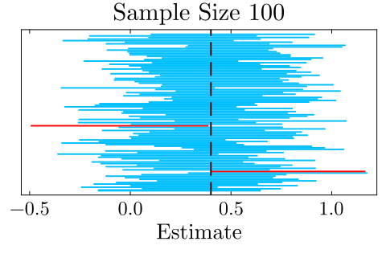

(a) Sample Size 100

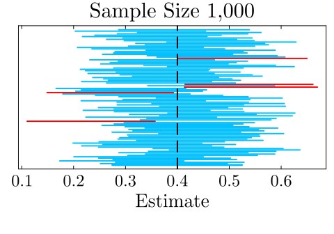

(b) Sample Size 1,000

Figure 5: Display of 95% confidence intervals

```julia
# set up distribution
mean_true = 0.4
n_cis = 100 # number of CIs to compute
dist = Normal(mean_true, 2)

# use sample size of 100
samples = rand(dist, (100, n_cis))
# mapslices broadcasts over a matrix dimension, could also use a loop
sample_means = mapslices(mean, samples; dims=1)
sample_sd = mapslices(std, samples; dims=1)
mc_sd = 1.96 * sample_sd / sqrt(100)
mc_ci = zeros(n_cis, 2) # preallocate
for i = 1:n_cis
    mc_ci[i, 1] = sample_means[i] - mc_sd[i]
    mc_ci[i, 2] = sample_means[i] + mc_sd[i]
end
# find which CIs contain the true value
ci_true = (mc_ci[:, 1] .< mean_true) .&& (mc_ci[:, 2] .> mean_true)
# compute percentage of CIs which contain the true value
ci_frac1 = 100 * sum(ci_true) ./ n_cis

# plot CIs
p1 = plot([mc_ci[1, :]], [1, 1], linewidth=3, color=:deepskyblue, label="95% Confidence Interval", title="Sample Size 100", yticks=:false, legend=:false)
for i = 2:n_cis
    if ci_true[i]
        plot!(p1, [mc_ci[i, :]], [i, i], linewidth=2, color=:deepskyblue, label=:false)
    else
        plot!(p1, [mc_ci[i, :]], [i, i], linewidth=2, color=:red, label=:false)
    end
end
vline!(p1, [mean_true], color=:black, linewidth=2, linestyle=:dash, label="True Value") # plot true value as a vertical line
xaxis!(p1, "Estimate")
plot!(p1, size=(500, 350)) # resize to fit slide

# use sample size of 1000
samples = rand(dist, (1000, n_cis))
# mapslices broadcasts over a matrix dimension, could also use a loop
sample_means = mapslices(mean, samples; dims=1)
sample_sd = mapslices(std, samples; dims=1)
mc_sd = 1.96 * sample_sd / sqrt(1000)
mc_ci = zeros(n_cis, 2) # preallocate
for i = 1:n_cis
    mc_ci[i, 1] = sample_means[i] - mc_sd[i]
    mc_ci[i, 2] = sample_means[i] + mc_sd[i]
end
# find which CIs contain the true value
ci_true = (mc_ci[:, 1] .< mean_true) .&& (mc_ci[:, 2] .> mean_true)
# compute percentage of CIs which contain the true value
ci_frac2 = 100 * sum(ci_true) ./ n_cis

# plot CIs
p2 = plot([mc_ci[1, :]], [1, 1], linewidth=3, color=:deepskyblue, label="95% Confidence Interval", title="Sample Size 1,000", yticks=:false, legend=:false)
for i = 2:n_cis
    if ci_true[i]
        plot!(p2, [mc_ci[i, :]], [i, i], linewidth=2, color=:deepskyblue, label=:false)
    else
        plot!(p2, [mc_ci[i, :]], [i, i], linewidth=2, color=:red, label=:false)
    end
end
vline!(p2, [mean_true], color=:black, linewidth=2, linestyle=:dash, label="True Value") # plot true value as a vertical line
xaxis!(p2, "Estimate")
plot!(p2, size=(500, 350)) # resize to fit slide

display(p1)
display(p2)
```

98% of the CIs contain the true value (left) vs. 95% (right)

## Constructing Confidence Intervals from Sampling Distributions

The key quantity is the **standard error** of a parameter, *e.g.* $\text{se}(\hat{\beta}_1)$.

The standard error is the standard deviation of the sampling distribution.

We call it the “error” to reflect that it is an “error” in estimating parameters.

## Standard Error Estimates

Of course, we also need to estimate the standard error since we don’t know the “true” values:

$$\hat{\text{se}}(\hat{\beta}_1) = \frac{\sigma}{\sqrt{n}s_X} \approx \frac{\hat{\sigma}}{\sqrt{n-2}s_X}$$

since $\frac{n}{n-2}\hat{\sigma}^2 \approx \sigma^2$.

## Predictive Intervals

Generate these using the conditional distributions based on probability model. An $\alpha$-distribution should contain $\alpha$% of new observations.

For example: find 90% interval by simulating samples from model and taking 5–95% quantiles.

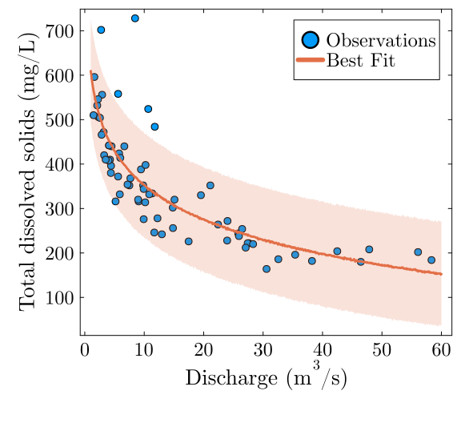

```julia
# simulate 10,000 predictions
x = 1:0.1:60
μ = θ_mle[1] .+ θ_mle[2] * log.(x)

y_pred = zeros(length(x), 10_000)
for i = 1:length(x)
    y_pred[i, :] = rand(Normal(μ[i], θ_mle[3]), 10_000)
end
# take quantiles to find prediction intervals
y_q = mapslices(v -> quantile(v, [0.05, 0.5, 0.95]), y_pred; dims=2)

p = scatter(
    tds.discharge_cms,
    tds.tds_mgL,
    xlabel=L"Discharge (m$^3$/s)",
    ylabel="Total dissolved solids (mg/L)",
    markersize=5,
    label="Observations",
    size = (600, 550)
)
plot!(x,
    y_q[:, 2],
    ribbon = (y_q[:, 2] - y_q[:, 1], y_q[:, 3] - y_q[:, 2]),
    linewidth=3,
    fillalpha=0.2,
    label="Best Fit",
    size=(600, 550))
```

# Key Points

## Probability Models

- Adding probabilistic assumptions lets us:
  - use maximum likelihood estimation;
  - Make probabilistic statements about parameters and predictions.
- Can find MLE by hand in some cases, but more often use numerical optimizers.
- For linear models (**and linear models only**) this gives the same result as OLS.

# Upcoming Schedule

## Next Classes

**Next Week**: More general probability models (including generalized linear models)

## Assessments

**Homework 1** Due **tonight**.

**Exercises**: Due before class Monday.

**Reading**: Shmueli (2010).

**Quiz 1**: Next Friday (2/13). Will include Monday’s content.

# References